# problemSet3

# GGPlot2 Diamonds Data Set

We need to perform some analysis on the ggplot2 diamonds data set to answer some questions.

**Questions:** - How many observations are in the data set? - How many variables are in the data set? - How many ordered factors are in the data set? - What letter represents the best diamond color?

## Load and Examine the data

```r
library(ggplot2)
data(diamonds)
summary(diamonds)
```

```
##      carat               cut        color        clarity
##  Min.   :0.2000   Fair     : 1610   D: 6775   SI1    :13065
##  1st Qu.:0.4000   Good     : 4906   E: 9797   VS2    :12258
##  Median :0.7000   Very Good:12082   F: 9542   SI2    : 9194
##  Mean   :0.7979   Premium  :13791   G:11292   VS1    : 8171
##  3rd Qu.:1.0400   Ideal    :21551   H: 8304   VVS2   : 5066
##  Max.   :5.0100                     I: 5422   VVS1   : 3655
##                                     J: 2808   (Other): 2531
##      depth           table           price             x
##  Min.   :43.00   Min.   :43.00   Min.   :  326   Min.   : 0.000
##  1st Qu.:61.00   1st Qu.:56.00   1st Qu.:  950   1st Qu.: 4.710
##  Median :61.80   Median :57.00   Median : 2401   Median : 5.700
##  Mean   :61.75   Mean   :57.46   Mean   : 3933   Mean   : 5.731
##  3rd Qu.:62.50   3rd Qu.:59.00   3rd Qu.: 5324   3rd Qu.: 6.540
##  Max.   :79.00   Max.   :95.00   Max.   :18823   Max.   :10.740
##
##        y                z
##  Min.   : 0.000   Min.   : 0.000
##  1st Qu.: 4.720   1st Qu.: 2.910
##  Median : 5.710   Median : 3.530
##  Mean   : 5.735   Mean   : 3.539
##  3rd Qu.: 6.540   3rd Qu.: 4.040
##  Max.   :58.900   Max.   :31.800
##
```

There are 53940 observations and 10 variables. Ordered factors inculude: cut, color, and clarity

color ranks include D, E, F, G, H, I, J

Which is best, let’s look at the included documentation.

```r
?diamonds
```

```
## starting httpd help server ... done
```

> colour. diamond colour, from J (worst) to D (best). So, D is the best.

## Create a Histogram of Diamond Prices

```r
library(ggthemes)
```

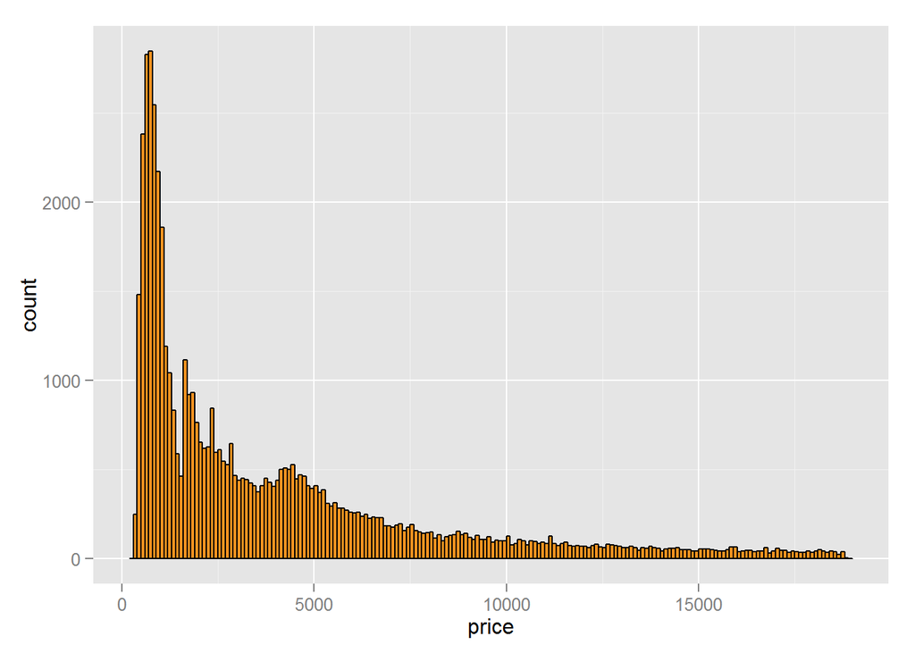

```r
ggplot(aes(x = price), data = diamonds) +
  geom_histogram(binwidth = 100,  color = 'black',fill = '#F79420')
```

Data is long-tailed, transforming onto log scale

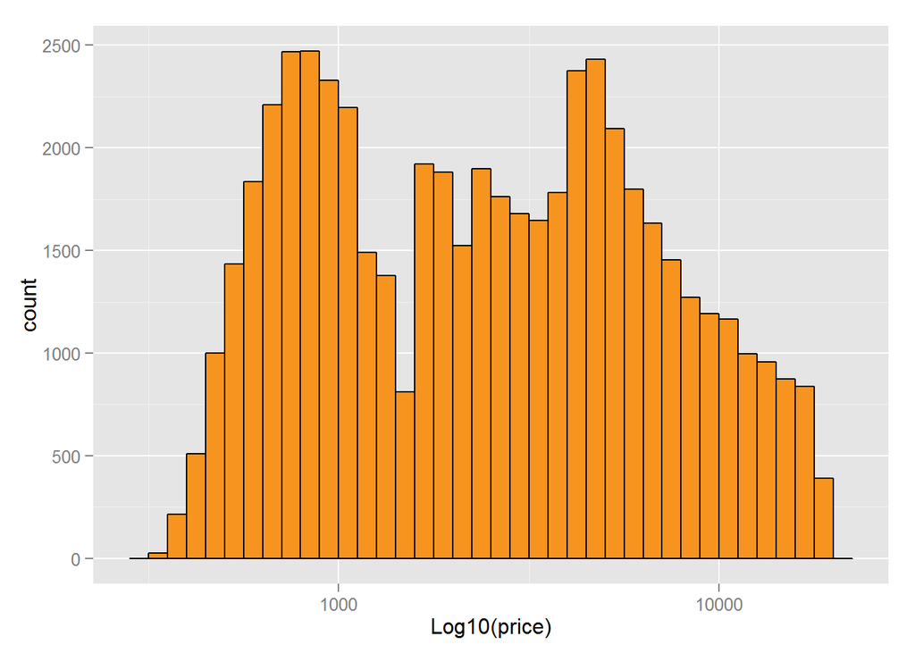

```r
ggplot(aes(x = price), data = diamonds) +
  geom_histogram(binwidth = .05,  color = 'black',fill = '#F79420') +
  scale_x_log10()+
  xlab('Log10(price)')
```

The data appears to be bimodal.

## Descriptive Statistics of Price

```r
summary(diamonds$price)
```

```
##    Min. 1st Qu.  Median    Mean 3rd Qu.    Max.
##     326     950    2401    3933    5324   18820
```

## Diamond Counts

How many diamonds cost less than 500 USD?

```r
nrow(subset(diamonds, diamonds$price < 500))
```

```
## [1] 1729
```

How many diamonds cost less than 250 USD?

```r
nrow(subset(diamonds, diamonds$price < 250))
```

```
## [1] 0
```

How many diamonds at least 15,000 USD?

```r
nrow(subset(diamonds, diamonds$price >= 15000))
```

```
## [1] 1656
```

## Eplore the largest Price Bin

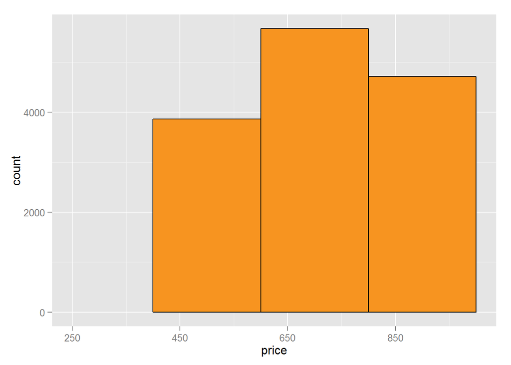

```r
ggplot(aes(x = price), data = diamonds) +
  geom_histogram(binwidth = 200,  color = 'black',fill = '#F79420') +
  scale_x_continuous(limits = c(250, 1000), breaks = seq(250, 1000, 200))
```

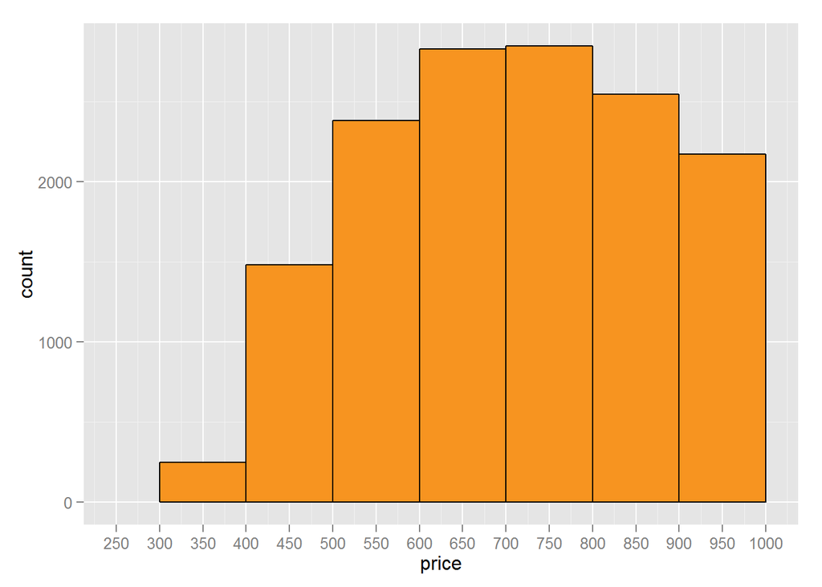

```r
ggplot(aes(x = price), data = diamonds) +
  geom_histogram(binwidth = 100,  color = 'black',fill = '#F79420') +
  scale_x_continuous(limits = c(250, 1000), breaks = seq(250, 1000, 50))
```

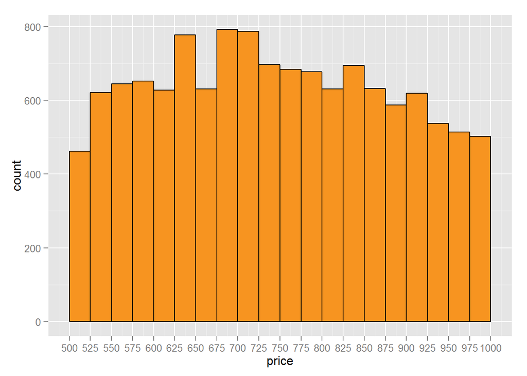

```r
ggplot(aes(x = price), data = diamonds) +
  geom_histogram(binwidth = 25,  color = 'black',fill = '#F79420') +
  scale_x_continuous(limits = c(500, 1000), breaks = seq(500, 1000, 25))
```

The last one is too granular. 600 to 800 USD seems to be the sweet spot for low end diamond prices.

**Insight provide from the class:**

> There are no diamonds that cost $1500. For diamonds that cost less than $2,000, the most common price of a diamond is >around $700 with the mode being $605 (binwidth = 1).